# Raw Data

```python
raw_data_path = "./data/20min-test-query-2020-jan-jun/raw-data/"
raw_file_name = "cd558cca-53cb-4ff9-a3f5-89f70e139051__2024_10_13T18_23_54.tsv"

# We can not share the full swissdox dataset, hence control the jupyter output while exporting
EXPORT = True
```

```python
import pandas as pd
import os
from pathlib import Path

import seaborn as sns
from collections import Counter
import lxml.html
from bs4 import BeautifulSoup
```

```python
with open(os.path.join(raw_data_path, raw_file_name)) as file:
    raw_file = file.readlines()

print(raw_file[0])
if EXPORT:
    print(raw_file[1].replace("\t", " <tab> ")[:60])
else:
    print(raw_file[1].replace("\t", " <tab> "))
```

```
id	pubtime	medium_code	medium_name	rubric	regional	doctype	doctype_description	language	char_count	dateline	head	subhead	article_link	content_id	content

38899273 <tab> 2020-02-10 08:28:00+01 <tab> ZWAO <tab> 20 mi
```

```python
df = pd.read_csv(os.path.join(raw_data_path, raw_file_name), sep="\t")
print(df.shape)
print(df.head(1).transpose())
```

```
(23555, 16)
                                                                     0
id                                                            38899273
pubtime                                         2020-02-10 08:28:00+01
medium_code                                                       ZWAO
medium_name                                          20 minuten online
rubric                                                             NaN
regional                                                           NaN
doctype                                                            WWE
doctype_description                                      Online medium
language                                                            de
char_count                                                         562
dateline                                            Singapore Airlines
head                            A380 muss wegen Orkantief durchstarten
subhead                                                            NaN
article_link         https://www.20min.ch/schweiz/zuerich/story/242...
content_id                        00028ac0-46af-cb40-908b-dedebaf3a9ea
content              <tx><ld><p>Sturmtief Sabine wirbelt den Plan d...
```

```python
print(df.info())
```

```
<class 'pandas.core.frame.DataFrame'>
RangeIndex: 23555 entries, 0 to 23554
Data columns (total 16 columns):
 #   Column               Non-Null Count  Dtype
---  ------               --------------  -----
 0   id                   23555 non-null  int64
 1   pubtime              23555 non-null  object
 2   medium_code          23555 non-null  object
 3   medium_name          23555 non-null  object
 4   rubric               0 non-null      float64
 5   regional             0 non-null      float64
 6   doctype              23555 non-null  object
 7   doctype_description  23555 non-null  object
 8   language             23555 non-null  object
 9   char_count           23555 non-null  int64
 10  dateline             23267 non-null  object
 11  head                 23555 non-null  object
 12  subhead              0 non-null      float64
 13  article_link         23554 non-null  object
 14  content_id           23555 non-null  object
 15  content              23555 non-null  object
dtypes: float64(3), int64(2), object(11)
memory usage: 2.9+ MB
None
```

```python
drop_nan_columns = ["rubric", "regional", "subhead"]
df = df.drop(drop_nan_columns, axis=1)
df.shape
```

```
(23555, 13)
```

```python
print(df.info())
```

```
<class 'pandas.core.frame.DataFrame'>
RangeIndex: 23555 entries, 0 to 23554
Data columns (total 13 columns):
 #   Column               Non-Null Count  Dtype
---  ------               --------------  -----
 0   id                   23555 non-null  int64
 1   pubtime              23555 non-null  object
 2   medium_code          23555 non-null  object
 3   medium_name          23555 non-null  object
 4   doctype              23555 non-null  object
 5   doctype_description  23555 non-null  object
 6   language             23555 non-null  object
 7   char_count           23555 non-null  int64
 8   dateline             23267 non-null  object
 9   head                 23555 non-null  object
 10  article_link         23554 non-null  object
 11  content_id           23555 non-null  object
 12  content              23555 non-null  object
dtypes: int64(2), object(11)
memory usage: 2.3+ MB
None
```

```python
df['content']
```

```
0        <tx><ld><p>Sturmtief Sabine wirbelt den Plan d...
1        <tx><ld><p>Les voisins chanteurs de la rotonde...
2        <tx><ld><p>Der Kanton Aargau führt im Kampf ge...
3        <tx><ld><p>Inmitten der anderen Automobile der...
4        <tx><ld><p>Le ministre de la santé Olivier Vér...
                               ...
23550    <tx><ld><p>La collecte de sapins de Noël a été...
23551    <tx><ld><p>Un porte-parole du Département fédé...
23552    <tx><ld><p>L'incendie d'un véhicule s'est prop...
23553    <tx><ld><p>Comme l'épidémie de Covid-19 se pou...
23554    <tx><ld><p>Tandis que certains ont critiqué le...
Name: content, Length: 23555, dtype: object
```

# Doctype

doctype doctype_description

```python
df.groupby(["doctype_description"]).count()
```

| doctype_description | id | pubtime | medium_code | medium_name | doctype | language | char_count | dateline | head | article_link | content_id | content |
| --- | --- | --- | --- | --- | --- | --- | --- | --- | --- | --- | --- | --- |
| Online medium | 23555 | 23555 | 23555 | 23555 | 23555 | 23555 | 23555 | 23267 | 23555 | 23554 | 23555 | 23555 |

This is not info which rubric this is from... Does this have to be scraped?  
Would be interesting but is it relevant?

# HTML Tag statistics

```python
def accumulate_counters(counter_list):
    accumulator_counter = Counter()
    for counter in counter_list:
        accumulator_counter += counter

    return accumulator_counter
```

```python
df_de = df[df["language"] == "de"]
df_fr = df[df["language"] == "fr"]

print(f"all: {df.shape}, de: {df_de.shape}, fr: {df_fr.shape}")
print(f"difference?: {len(df) - len(df_de) - len(df_fr)}")
```

```
all: (23555, 13), de: (8044, 13), fr: (15511, 13)
difference?: 0
```

```python
df_de.content[0:10]
```

```
0     <tx><ld><p>Sturmtief Sabine wirbelt den Plan d...
2     <tx><ld><p>Der Kanton Aargau führt im Kampf ge...
3     <tx><ld><p>Inmitten der anderen Automobile der...
5     <tx><ld><p>Auf der Galápagos-Insel Fernandina ...
10    <tx><ld><p>Ein neues Restaurierungs-Fiasko bri...
12    <tx><ld><p>Ein 21-Jähriger verlor in der Nacht...
15    <tx><ld><p>Von Stress bis Loco Escrito – edle ...
22    <tx><ld><p>In Anlehnung an die Kinderbuchserie...
25    <tx><ld><p>Über zwei Jahre versteckte er sich....
26    <tx><ld><p>Hans Peter musste mit seinem Velo e...
Name: content, dtype: object
```

```python
for row in df_de["content"].iloc[0:10]:
    print(row) if not EXPORT else None
```

```python
get_html_tag_occurence = lambda content: Counter({element.tag for element in lxml.html.fromstring(content).iter()})
tag_occurence = list(df_de["content"].apply(get_html_tag_occurence))
accumulator_occurence = accumulate_counters(tag_occurence)
pd.DataFrame(accumulator_occurence, index=["counts"]).sort_values(by=["counts"], ascending=False, axis=1)
```

|  | p | tx | ld | zt | a | br | ka | lg | au |
| --- | --- | --- | --- | --- | --- | --- | --- | --- | --- |
| counts | 8044 | 8044 | 8043 | 5175 | 4062 | 2382 | 1684 | 826 | 732 |

- Every article has the following:
  - tx -> whole text wrapped
  - ld -> lead text (except one article)
  - p -> multiple text elements
    - If there is a last element with brackets this might be one or multiple authors:
      - `<p>(SDA)</p></tx>`
- The other tags should be checked if there is something relevant extractable
  - zt -> zwischentitel(subheading)
  - a -> anchor -> links to
    - other websites or
    - other articles `<a href="#showid=305209&amp;index=0">La Cumbre-Ausbruch bedroht seltene Tierarten</a>` -> not sure what this is referencing
    - other articles `<a href="https://www.20min.ch/ausland/news/story/Saemtliche-Fluege-wegen-Vulkanausbruch-anulliert-22651640">Taal</a>`
  - br -> breaks
    - These breaks are also part of twitter messages, as indicated by `<ka>`  
      `<ka><p>¡Hey! ??<br/><br/>Tiempo de jugar... ??<br/><br/>¿Nos`...
  - ka -> external embeddings?
    - also a "darum gehts" box as indicated by:
      - `<ka><p>Darum gehts</p><p>`
      - each bullet point has their own `<p>...</p>`
  - lg -> lead graphic (text of first picture on the article) -> include/exclude?
  - au -> author full name (not short name as in last p element)

Does it look similar for the french version?

```python
get_html_tag_occurence = lambda content: Counter({element.tag for element in lxml.html.fromstring(content).iter()})
tag_occurence = list(df_fr["content"].apply(get_html_tag_occurence))
accumulator_occurence = accumulate_counters(tag_occurence)
pd.DataFrame(accumulator_occurence, index=["counts"]).sort_values(by=["counts"], ascending=False, axis=1)
```

|  | p | tx | ld | zt | a | ka | br | lg | au |
| --- | --- | --- | --- | --- | --- | --- | --- | --- | --- |
| counts | 15511 | 15511 | 15509 | 9230 | 6275 | 2646 | 1626 | 1411 | 547 |

Yes it looks simlilar.

```python
get_html_tag_counts = lambda content: Counter(element.tag for element in lxml.html.fromstring(content).iter())
tags_counts = list(df_de["content"].apply(get_html_tag_counts))

tags_counts[:4]
```

```
[Counter({'p': 4, 'br': 2, 'tx': 1, 'ld': 1}),
 Counter({'p': 9, 'zt': 2, 'tx': 1, 'ld': 1, 'br': 1}),
 Counter({'p': 11, 'zt': 4, 'tx': 1, 'ld': 1}),
 Counter({'p': 10, 'a': 6, 'br': 2, 'tx': 1, 'ld': 1, 'zt': 1})]
```

```python
accumulator_counter = accumulate_counters(tags_counts)
plot_df = pd.DataFrame(accumulator_counter, index=["counts"]).sort_values(by=["counts"], ascending=False, axis=1)
plot_df
```

|  | p | a | zt | br | tx | ld | ka | lg | au |
| --- | --- | --- | --- | --- | --- | --- | --- | --- | --- |
| counts | 80463 | 12938 | 10152 | 8841 | 8044 | 8043 | 2788 | 2459 | 732 |

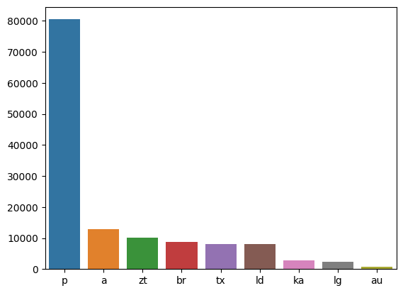

```python
sns.barplot(plot_df)
```

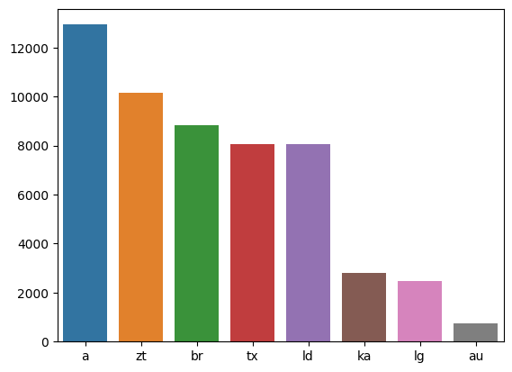

```python
sns.barplot(plot_df.drop(["p"], axis=1))
```

# Let us also extract the following:

- `<ld>`: lead text
- last `<p>` if encased in (): author(s)
- `<zt>`: subheadings
- `<ka>`: differentiate if external website or not

what is lg and au?

```python
def get_lg(article:str):
    soup = BeautifulSoup(article)
    if soup.lg:
        return soup.lg.string
    else:
        return None

series_lg = df_de["content"].apply(get_lg)

for row in series_lg[~series_lg.isnull()].iloc[0:3]:
    print(row)
```

```
Dies war das Beste, was der anscheinend völlig überforderte Restaurator …Screenshot
Negativer Asylentscheid: Arezu Eljasi muss die Schweiz verlassen.zvg
Anthony Martial brachte Manchester United mit seinem Hattrick gegen Sheffield den Sieg.Foto: Getty Images
```

```python
def get_au(article:str):
    soup = BeautifulSoup(article)
    if soup.au:
        return soup.au.string
    else:
        return None

series_au = df_de["content"].apply(get_au)

for row in series_au[~series_au.isnull()].iloc[0:3]:
    print(row)
```

```
Simon Ulrich
Matteo Bonomo
Raphael Casablanca
```

```python
print("articles with multiple authors:", series_au[~series_au.isnull()].str.contains(",").sum())
series_au.groupby(series_au).count().sort_values()
```

```
articles with multiple authors: 41
```

```
content
20min                                        1
Oliver Braams, Felix Traber                  1
Noah Knüsel, Lena Stadler, Pascal Michel     1
Nils Hänggi, Etienne Sticher                 1
Nicole Ulrich, Tunya Koch                    1
                                            ..
Dominique Zeier                             19
Gamze Ibis                                  19
Jil Rietmann                                20
Sven Forster                                23
Bianca Lüthy                                35
Name: content, Length: 162, dtype: int64
```

```python
def get_lead(article:str ):
    soup = BeautifulSoup(article)
    if soup.ld:
        return soup.ld.string
    else:
        return None
```

```python
df_de["content"].apply(get_lead)
```

```
0        Sturmtief Sabine wirbelt den Plan des Flughafe...
2        Der Kanton Aargau führt im Kampf gegen die Cor...
3        Inmitten der anderen Automobile der 1960er-Jah...
5        Auf der Galápagos-Insel Fernandina ist der Vul...
10       Ein neues Restaurierungs-Fiasko bringt in Span...
                               ...
23534    «... Jetzt will ich Apple zerstören», sagt der...
23538    Junge Frauen berichten, dass sie während der C...
23540    Die Horrorapp aus «Countdown» gibts wirklich, ...
23541    Weltweit suchen Forscher nach Medikamenten zur...
23549    Der ehemalige «Victorious»-Cast feierte per Vi...
Name: content, Length: 8044, dtype: object
```

```python
def get_authors(article:str):
    """ If the last <p> element encapsulates any text with "()" then
        this text is split by eitehr "," or "/" into a list of authors."""
    soup = BeautifulSoup(article)
    if soup.p:
        last_p =  soup.find_all("p")[-1].text
        if last_p[0] == "(" and last_p[-1] == ")":
            inner_last_p = last_p[1:-1]
            if "," in inner_last_p:
                return_value = inner_last_p.split(",")
            elif "/" in last_p[1:-1]:
                return_value = inner_last_p.split("/")
            else:
                return_value = [inner_last_p]

            # sanity check, there should hopefully not be a broken up string
            if len(return_value) > 3:
                print(return_value)

            return return_value
        else:
            return None
    else:
        return None
```

```
['mme', 'dag', 'jab', 'nak', 'sda']
['ete', 'mal', 'jch', 'erh', 'rha']
['dk', 'lem', 'mon', 'wed']
['kro', 'zen', 'kfi', 'anh', 'shy', 'fim']
['vro', 'rab', 'kat', 'sda']
['ädu', 'mal', 'sg.', 'mob']
['mon', 'zos', 'tam', 'wed']
['kle', 'chk', 'fss', 'sda']
['rab', 'gab', 'lha', 'sda']
['dpa', 'nih', 'cef', 'te', 'ets']
['dmo', 'scl', 'vro', 'sda']
['fss', 'kat', 'kle', 'vro']
['dpa', 'nih', 'cef', 'te', 'ets']
['kro', 'zen', 'kfi', 'anh', 'shy', 'fim']
['kka ', ' fah ', ' mal ', ' pmu']
```

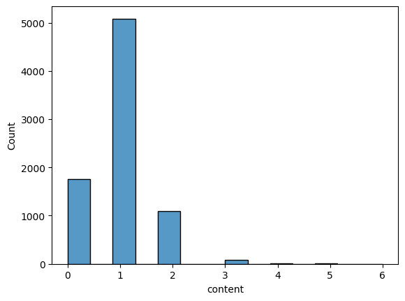

```python
authors_per_article = df_de["content"].apply(get_authors)
num_authors = authors_per_article.apply(lambda x: len(x) if x else 0)
sns.histplot(num_authors)
```

```python
authors_per_article.isna().sum()
```

```
1765
```

```python
# validate nonstandard authors that are not 2 or 3 chars
for r in authors_per_article:
    if not r:
        continue

    if not any([True for x in r if "/" in x]):
        if len(r) == 1 and not (len(r[0]) == 3 or len(r[0]) == 2 ):
            print(r)
```

```
['20 Minuten']
['20 Minuten']
['Reuters']
['20 Minuten']
['20 Minuten']
['20 Minuten']
['20 Min']
['heute.at']
['reuters']
['20 Minuten']
['Reuters']
['20 Minuten']
['20 Minuten']
['Reuters']
['20 Minuten']
['20 Minuten']
['20 Minuten']
['20 Minuten']
['20 Minuten']
['20 Minuten']
['20 Minuten']
['20 Minuten']
['heute.at']
['REUTERS']
['Reuters']
['20 Minuten']
['gusi']
['20 Minuten']
['20 Minuten']
['20 Minuten']
['20 Minuten']
['20 Minuten']
['20 Minuten']
['20 Minuten']
['20 Minuten']
['heute.at']
['REUTERS']
['20 Minuten']
['20 Minuten']
['20 Minuten']
```

[output cut: 79 more lines]

```
['20 Minuten']
['20 Minuten']
['20 Minuten']
['lha jd']
['gusi']
['gusi']
['20 Minuten']
['Reuters']
['heute.at']
['gusi']
[' bgy']
['Heute']
['20 Minuten']
['20 Minuten']
['20 Minuten']
```

Check overlap of `<au>` and extracted authors

```python
print("Total matches are more than the samples in the dataframe: ", authors_per_article.isna().sum() +series_au.isna().sum())
```

```
Total matches are more than the samples in the dataframe:  9078
```

```python
print("number of overlapping: ", sum(~authors_per_article.isna() & ~series_au.isna()))
```

```
number of overlapping:  30
```

```python
print("number of both empty: ", sum(authors_per_article.isna() & series_au.isna()))
```

```
number of both empty:  1064
```

```python
# Overlap is basically SDA, Reuters and DPA... in series_au, authors it is people
authors_per_article[~authors_per_article.isna() & ~series_au.isna()].head(10)
```

```
403         [SDA]
476     [Reuters]
1011        [SDA]
1267        [SDA]
1554        [SDA]
1895        [SDA]
2854        [SDA]
2893        [SDA]
3089        [DPA]
3138        [SDA]
Name: content, dtype: object
```

```python
print("overlap example:")
for url in df_de[authors_per_article.isna() & series_au.isna()]["article_link"].iloc[-10:]:
    print(url)



"""for row in df_de["content"].iloc[0:10]:
    print(row)"""
```

```
overlap example:
https://www.20min.ch/schweiz/news/story/30432018
https://www.20min.ch/entertainment/starticket/story/23971153
http://www.20min.ch/entertainment/starticket/story/24864380
http://www.20min.ch/finance/news/story/17828579
http://www.20min.ch/schweiz/news/story/21565217
http://www.20min.ch/schweiz/news/story/22267041
http://www.20min.ch/sport/tennis/story/23930757
http://www.20min.ch/sport/fussball/story/21344601
https://www.20min.ch/motor/news/story/16852652
http://www.20min.ch/schweiz/news/story/19488961
```

```
'for row in df_de["content"].iloc[0:10]:\n    print(row)'
```

```python
def get_subheadings(article:str):
    soup = BeautifulSoup(article)
    if soup.zt:
        return [zt.text for zt in soup.find_all("zt")]
    else:
        return None
```

```python
res = df_fr["content"].apply(get_subheadings)
res[4]
```

```
["50'000 tests par jour", '«Mots scandaleux»']
```

```python
res[0:10]
```

```
1                                                  None
4            [50'000 tests par jour, «Mots scandaleux»]
6                                                  None
7                                                  None
8                     [#MeToo, Des «démons» intérieurs]
9                                                  None
11                                                 None
13    [Munich empile les records, M'Gladbach en Ligu...
14                                   [D'autres actions]
16                              [Prix Renaudot en 1997]
Name: content, dtype: object
```

# Conclusion on HTML tags

### Available tags:

- tx -> whole text wrapped
  - just remove the tag itself
- ld -> lead text
  - extract to column
- p -> multiple text elements
  - just remove the tags
- p -> last element iff matches authors
  - remove the authors and extract to column
- zt -> zwischentitel(subheading)
  - extract to column
- a -> anchor
  - remove the urls but keep the annotated text within tag
- br -> breaks
  - remove the tags
- ka -> external embeddings?
  - remove the tags
- lg -> lead graphic (text of first picture on the article) -> include/exclude?
  - strip out content of tag, this is in reference to one of many images
- au -> author full name (not short name as in last p element)
  - for now: create second column since the overlap with extracted authors from last `<p>` and `<au>` is small but `SDA`, `Reuters`... vs `<human name>`

# New Columns should be:

- id
- pubtime
- language
- char_count
- dateline
- head
- article_link
- content
- lead_text
- subheadings
- author_extracted (extracted from last `<p>`)
- author (extracted from `<au>` tag)
- text (cleaned `content`)
  - remove just tags:
    - `<tx>`
    - `<br>`
    - `<ka>`
  - remove substring from content
    - last `<p>` if it is a match for author filter
    - urls from `<a>` tag -> check if general html tag remover also does this easily
    - `<lg>` text since it is related to the image not the article.